# Lecture 1

6 January 2021

## Structure

- Introduction & Course Overview
- Project suggestions
- ML intro
- ETL process

## Introduction & Course Overview

## About me

- Michal Kubišta
- Main focus: European FMCG retail market
- Contact: michal.kubista@nielsen.com
- Office hours: upon prior arrangment
- I’m bad with names … *sorry*
- **please include string “MLT2021” in your email subject**

## Organization

- Wednesday: 16:15 - 19:30
- Friday: 9:30 - 11:00
  - additional seminar used to wrap up more complex topics
  - otherwise can be used for consultations

## Content

- topics in marketing analysis
  - customer segmentation
  - pricing strategies
- algorithms
  - distance-based techniques
  - CART type algorithms
  - neural networks
- ETL process

## Grading

- project - *no worries in the exam period*
- 4 deadlines
  - describe your project (15 p)
  - get and clean the data (25 p)
  - analyse (40 p)
  - present (20 p)
- **conditions to pass**
  - at least 60p in total
  - at least 60 % at each deadline
- submit via Github

## Grading - project description

- documentation
- what will you analyse (churn, baskets, prices)
  - what data will be used
- why (predict churn, optimise prices)
- how (logit, mixed-effects lm)
- outcome discussion

## Grading - data & tidiness

- sufficiency = “can the analysis be done with this data?”
  - use **several sources**
- reproducibility
  - try to get the data through R, or include all the sources (links)
- [tidy data](http://vita.had.co.nz/papers/tidy-data.pdf) - more on that in the second part
- **don’t erase used commands & comment extensively**
  - I want to see all the used commands (e.g. *summary*, *str*)
  - comment what is happening and how will you handle it
  - it is part of the flow of the project & it helps me understand that you know what you are doing
- feature engineering and train-test splitting can be done later
- objective: data already prepare for the algorithm run

## Grading - analysis

- usage of the model
  - should be discussed in advance
- understanding the process
  - all the cross-validation, parameter tuning, …
  - why am I using this value for parameter “xy”?
  - if several possible values, **discuss**
- **don’t erase used commands & comment extensively**
  - I want to see all the used commands
  - comment what is happening and how to handle it
  - it is part of the flow of the project & it helps me understand that you know what you are doing
- model results interpretation

## Why commenting?

[figure not shown]

## Grading - final output

- presented in the class
- co-evaluated by your classmates
- prepare :
  - problem overview
  - methodology introduction and discussion
  - nice visualisations (you want to sell your product)

## Bonus points

- few options during the course
- play a game, prove some theory, calculate, suggest an approach
- in a form of home assignments
- achieving more than 100% score results in some sweet reward
- will not save you from failing
- this week:
  - play the game **CastleOfR** (originally written by [Giora Simchoni](https://github.com/gsimchoni/CastleOfR))
  - *what do the dragons like?*
  - email me the answer and get the points
  - 2p up for the final grade

## Github

- you should already have an account
- [check the repo](https://github.com/CERGE-MAE/MLT) (and watch it)
- download the slides (sources)
- should you find any mistke in the materials
  - suggest edit via pull request
- submit done via [Github classroom](https://classroom.github.com/a/cQSDmmhK)

**Questions?**

## Project suggestions

## Sample projects

- recommendation systems
  - get the ratings and movie features
  - data overview
  - build several models (w3)
  - combine predictions
- basket analysis
  - data overview
    - enrich by weather data?
  - product &| customer segmentation (w4)
  - association rules (w2)
  - personalised offers (w3)

## Sample projects (ii)

- pricing analysis
  - data overview
    - enrich by weather data?
  - product segmentation (w4) / ranking (pareto)
  - pricing strategy (w6)
- customer loyalty / churn
  - data overview
  - (price and promotion) segmentation (w4)
    - shopping missions
  - churn analysis (w7)

## ML intro

## What do machines learn?

supervised learning

- regression
- classification

unsupervised

- clustering
- mapping

## How do machines learn?

- optimisation
  - highest accuracy
  - lowest variance

RMSE = \(\sqrt{\frac{\sum_{i=1}^{n}e_i^2}{n}}\)  
R^2 = \(1 - \frac{SSR}{SST}\)  
acc = \(\frac{\sum_{i=1}^{n} 1 - |\hat y_i - y_i|}{n}\)  
entrophy = \(\sum_{i=1}^{J}-p_i * log_2(p_i)\)  
gini = \(1 - \sum_{i=1}^{J} p_i^2\)

## Regression problems?

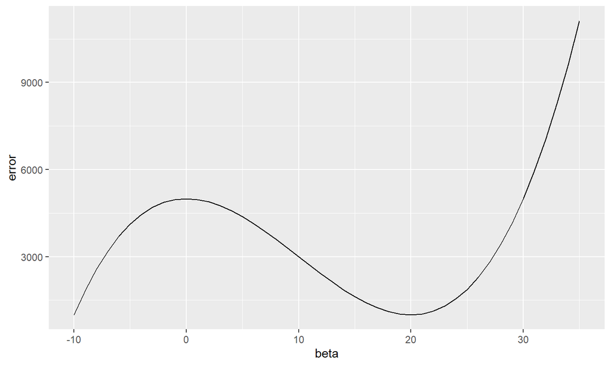

## Classification problems?

Assume that 0.1 % of population has an illness.  
We want to build a model that will predict (based on some symptoms),  
whether the individual is healthy or not.

Our model is able to predict with 99.9 % accuracy.

- What is the problem?
- It doesn’t predict anything…

## Classification problems?

Assume that 0.1 % of population has an illness.  
We want to build a model that will predict (based on some symptoms),  
whether the individual is healthy or not.

- so called inbalanced classification
  - the most accurate prediction is to say everyone is healthy
  - not very helpful
- how to spot?
  - EDA
  - confusion matrix

```
##          pred=1 pred=0
## actual=1 999000      0
## actual=0   1000      0
```

## Classification problems?

Assume that 0.1 % of population has an illness.  
We want to build a model that will predict (based on some symptoms),  
whether the individual is healthy or not.

- how to solve it?
  - oversample?
  - undersample?
  - hybrid
  - weighting

## Statistics vs ML?

**stats**

- based on mathematical methods
- very strict framework
- sometimes your best option

**ML**

- based on computer methods
- loose framework
- working in limit (assymptotic)

## Statistics vs ML? (ii)

- estimation vs measuring the error
  - efficiency
- assumptions vs data

## Overfitting

- variance bias trade-off
- complexity vs accuracy
- concept similar to degrees of freedom

## ETL process

## The most important step of the project

- find the data?
- find the best algorithm for the analysis?
- visualisation and meaningful insights?
- something completely different?

## Loading the data!

## What now?

- data can’t be read into R
- no metadata available
- file too large to be opened in common tools (notepad, excel)

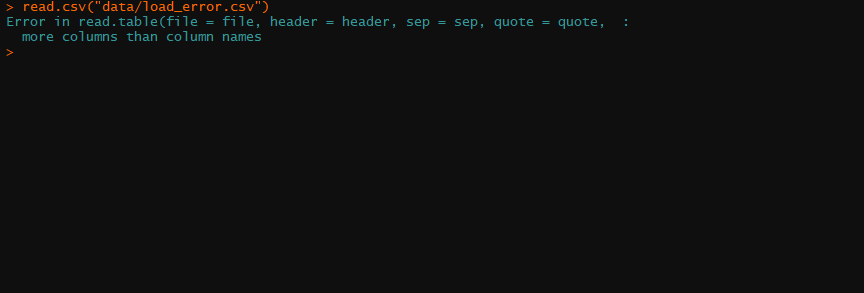

## Column error? => header & fill

```r
read.csv("data/lecture/load_error.csv", header = FALSE, fill = TRUE)
```

```
##        V1      V2      V3 V4 V5
## 1 header1 header2 header3 NA NA
## 2     abc       1       2 NA NA
## 3     bcd       1       2 NA NA
## 4     cde       1       2  3  4
```

## Line-specific error? => skip & nrows

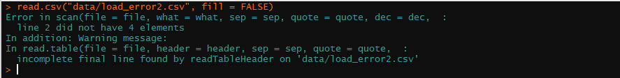

```r
read.table("data/lecture/load_error2.csv", fill = FALSE, skip = 1, nrows = 2)
```

```
##        V1
## 1 a,b,c,d
## 2 a;b;c;d
```

## Encoding problem?

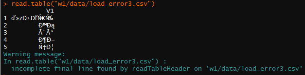

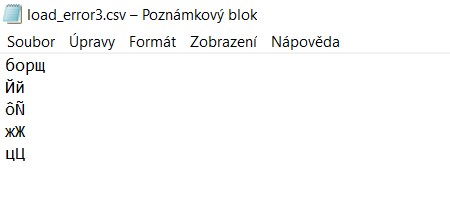

## Encoding solution

```r
read.table("data/lecture/load_error3.csv",
           encoding = "UTF-8",
           stringsAsFactors = FALSE)
```

```
##                                         V1
## 1 борщ
## 2                         Йй
## 3                                       ôN
## 4                         жЖ
## 5                         цЦ
```

- more on encoding [here](https://www.joelonsoftware.com/2003/10/08/the-absolute-minimum-every-software-developer-absolutely-positively-must-know-about-unicode-and-character-sets-no-excuses/) & [here](http://kunststube.net/encoding/)

## Unknown separators?

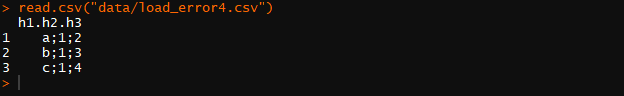

- becomes problem with large files
- readLines

## Any other troubles?

- readLines
- fread (data.table package)
- **good luck**